# Sleep Health and Lifestyle

## 1. Introduction

Sleep quality and overall health are strongly influenced by lifestyle habits and physiological factors. Poor sleep and high stress are linked to obesity, cardiovascular problems, and reduced cognitive performance. The purpose of this project is to explore how demographic, lifestyle, and physiological variables relate to sleep health and to develop predictive models that estimate the likelihood of sleep disorders. This analysis can help identify key risk factors and support early interventions for better health outcomes.Sleep quality and overall health are strongly influenced by lifestyle habits and physiological factors. Poor sleep and high stress are linked to obesity, cardiovascular problems, and reduced cognitive performance.

The purpose of this project is to explore how demographic, lifestyle, and physiological variables relate to sleep health and to develop predictive models that estimate the likelihood of sleep disorders.

The analysis will use machine learning methods including K-Nearest Neighbors, Random Forest, Support Vector Machine, and Neural Networks. This approach can help identify key risk factors and support early interventions for better health outcomes.

## Variables Description

- **Person ID:** Unique identifier for each individual.
- **Gender:** Gender of the individual (e.g., Male, Female).
- **Age:** Age in years.
- **Occupation:** Occupation of the individual.
- **Sleep Duration:** Average sleep duration per night in hours.
- **Quality of Sleep:** Self-rated sleep quality (scale 1–10).
- **Physical Activity Level:** Physical activity level (scale 1–100).
- **Stress Level:** Self-rated stress level (scale 1–10).
- **BMI Category:** BMI category (Underweight, Normal, Overweight, Obese).
- **Blood Pressure:** Blood pressure in mmHg.
- **Heart Rate:** Heart rate in beats per minute.
- **Daily Steps:** Number of steps per day.
- **Sleep Disorder:** Presence of any sleep disorders (e.g., None, Insomnia, Sleep Apnea)

```python
### --- Import packages ---


import numpy as np
import pandas as pd
import matplotlib.pyplot as plt
import seaborn as sns
from sklearn.model_selection import train_test_split, GridSearchCV, StratifiedKFold
from sklearn.preprocessing import StandardScaler, LabelEncoder
from sklearn.metrics import confusion_matrix, classification_report, accuracy_score, cohen_kappa_score, precision_score, recall_score, f1_score
import tensorflow as tf
from tensorflow import keras
from tensorflow.keras import layers, Sequential

from sklearn.neighbors import KNeighborsClassifier
from sklearn.ensemble import RandomForestClassifier
import statsmodels.api as sm
from sklearn.svm import SVC
```

```python
### --- Load dataset ---

data = pd.read_csv("Sleep_health_and_lifestyle_dataset.csv")
```

```python
data.head()
```

|  | Person ID | Gender | Age | Occupation | Sleep Duration | Quality of Sleep | Physical Activity Level | Stress Level | BMI Category | Blood Pressure | Heart Rate | Daily Steps | Sleep Disorder |
| --- | --- | --- | --- | --- | --- | --- | --- | --- | --- | --- | --- | --- | --- |
| 0 | 1 | Male | 27 | Software Engineer | 6.1 | 6 | 42 | 6 | Overweight | 126/83 | 77 | 4200 | None |
| 1 | 2 | Male | 28 | Doctor | 6.2 | 6 | 60 | 8 | Normal | 125/80 | 75 | 10000 | None |
| 2 | 3 | Male | 28 | Doctor | 6.2 | 6 | 60 | 8 | Normal | 125/80 | 75 | 10000 | None |
| 3 | 4 | Male | 28 | Sales Representative | 5.9 | 4 | 30 | 8 | Obese | 140/90 | 85 | 3000 | Sleep Apnea |
| 4 | 5 | Male | 28 | Sales Representative | 5.9 | 4 | 30 | 8 | Obese | 140/90 | 85 | 3000 | Sleep Apnea |

```python
data.tail()
```

|  | Person ID | Gender | Age | Occupation | Sleep Duration | Quality of Sleep | Physical Activity Level | Stress Level | BMI Category | Blood Pressure | Heart Rate | Daily Steps | Sleep Disorder |
| --- | --- | --- | --- | --- | --- | --- | --- | --- | --- | --- | --- | --- | --- |
| 369 | 370 | Female | 59 | Nurse | 8.1 | 9 | 75 | 3 | Overweight | 140/95 | 68 | 7000 | Sleep Apnea |
| 370 | 371 | Female | 59 | Nurse | 8.0 | 9 | 75 | 3 | Overweight | 140/95 | 68 | 7000 | Sleep Apnea |
| 371 | 372 | Female | 59 | Nurse | 8.1 | 9 | 75 | 3 | Overweight | 140/95 | 68 | 7000 | Sleep Apnea |
| 372 | 373 | Female | 59 | Nurse | 8.1 | 9 | 75 | 3 | Overweight | 140/95 | 68 | 7000 | Sleep Apnea |
| 373 | 374 | Female | 59 | Nurse | 8.1 | 9 | 75 | 3 | Overweight | 140/95 | 68 | 7000 | Sleep Apnea |

```python
data.info()
```

```
<class 'pandas.core.frame.DataFrame'>
RangeIndex: 374 entries, 0 to 373
Data columns (total 13 columns):
 #   Column                   Non-Null Count  Dtype
---  ------                   --------------  -----
 0   Person ID                374 non-null    int64
 1   Gender                   374 non-null    object
 2   Age                      374 non-null    int64
 3   Occupation               374 non-null    object
 4   Sleep Duration           374 non-null    float64
 5   Quality of Sleep         374 non-null    int64
 6   Physical Activity Level  374 non-null    int64
 7   Stress Level             374 non-null    int64
 8   BMI Category             374 non-null    object
 9   Blood Pressure           374 non-null    object
 10  Heart Rate               374 non-null    int64
 11  Daily Steps              374 non-null    int64
 12  Sleep Disorder           374 non-null    object
dtypes: float64(1), int64(7), object(5)
memory usage: 38.1+ KB
```

```python
data.describe()
```

|  | Person ID | Age | Sleep Duration | Quality of Sleep | Physical Activity Level | Stress Level | Heart Rate | Daily Steps |
| --- | --- | --- | --- | --- | --- | --- | --- | --- |
| count | 374.000000 | 374.000000 | 374.000000 | 374.000000 | 374.000000 | 374.000000 | 374.000000 | 374.000000 |
| mean | 187.500000 | 42.184492 | 7.132086 | 7.312834 | 59.171123 | 5.385027 | 70.165775 | 6816.844920 |
| std | 108.108742 | 8.673133 | 0.795657 | 1.196956 | 20.830804 | 1.774526 | 4.135676 | 1617.915679 |
| min | 1.000000 | 27.000000 | 5.800000 | 4.000000 | 30.000000 | 3.000000 | 65.000000 | 3000.000000 |
| 25% | 94.250000 | 35.250000 | 6.400000 | 6.000000 | 45.000000 | 4.000000 | 68.000000 | 5600.000000 |
| 50% | 187.500000 | 43.000000 | 7.200000 | 7.000000 | 60.000000 | 5.000000 | 70.000000 | 7000.000000 |
| 75% | 280.750000 | 50.000000 | 7.800000 | 8.000000 | 75.000000 | 7.000000 | 72.000000 | 8000.000000 |
| max | 374.000000 | 59.000000 | 8.500000 | 9.000000 | 90.000000 | 8.000000 | 86.000000 | 10000.000000 |

## 2. Explore and Preprocess

### visualise distribution

These plots provide an overview of how each variable is represented within the sample, enabling the identification of data patterns, variability, and potential imbalances.

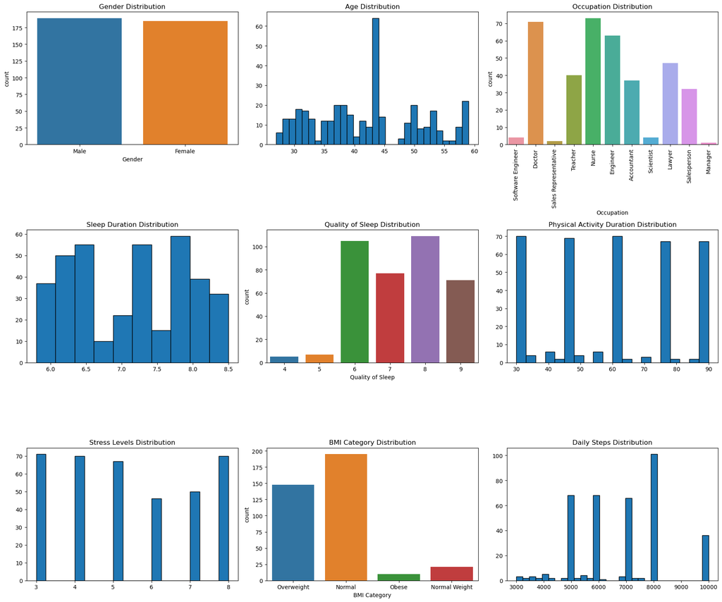

```python
plt.figure(figsize=(18, 15))

# Gender Distribution
plt.subplot(3, 3, 1)
sns.countplot(data=data, x="Gender")
plt.title("Gender Distribution")

# Age Distribution
plt.subplot(3, 3, 2)
plt.hist(data["Age"], bins=30, edgecolor='black')
plt.title("Age Distribution")

# Occupation Distribution
plt.subplot(3, 3, 3)
sns.countplot(data=data, x="Occupation")
plt.title("Occupation Distribution")
plt.xticks(rotation=90)

# Sleep Duration
plt.subplot(3, 3, 4)
plt.hist(data["Sleep Duration"], bins=10, edgecolor='black')
plt.title("Sleep Duration Distribution")

# Quality of Sleep
plt.subplot(3, 3, 5)
sns.countplot(data=data, x="Quality of Sleep")
plt.title("Quality of Sleep Distribution")

# Physical Activity
plt.subplot(3, 3, 6)
plt.hist(data["Physical Activity Level"], bins=20, edgecolor='black')
plt.title("Physical Activity Duration Distribution")

# Stress Level
plt.subplot(3, 3, 7)
plt.hist(data["Stress Level"], bins=20, edgecolor='black')
plt.title("Stress Levels Distribution")

# BMI Category
plt.subplot(3, 3, 8)
sns.countplot(data=data, x="BMI Category")
plt.title("BMI Category Distribution")

# Daily Steps
plt.subplot(3, 3, 9)
plt.hist(data["Daily Steps"], bins=30, edgecolor='black')
plt.title("Daily Steps Distribution")

plt.tight_layout()
plt.show()
```

The graphs show a balanced gender distribution and a wide adult age range. Occupations vary across several categories. Most participants report sleeping between 6 and 8 hours with moderate to high sleep quality. Physical activity levels and stress levels are broadly distributed. BMI categories are mainly concentrated in normal and overweight groups, and daily step counts vary substantially. Overall, the distributions indicate a diverse sample with varied lifestyle and health characteristics.

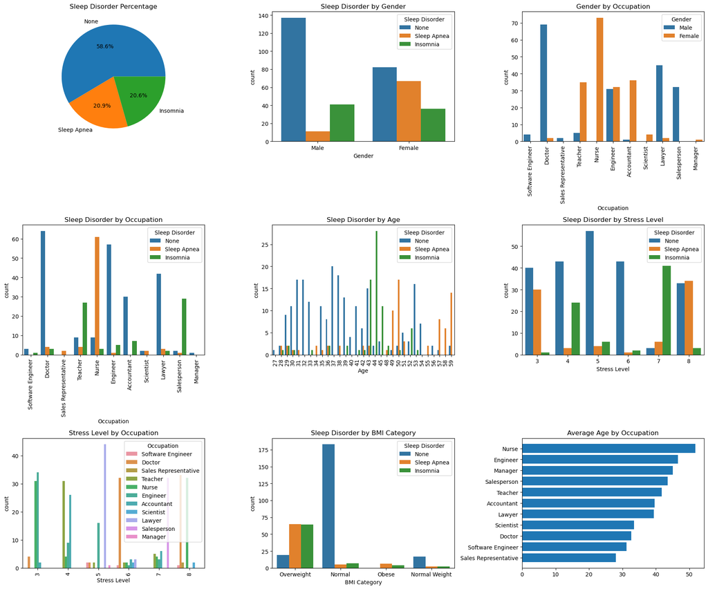

```python
plt.figure(figsize=(18, 15))

# Sleep Disorder percentage
plt.subplot(3, 3, 1)
percentage_table = data["Sleep Disorder"].value_counts(normalize=True) * 100
plt.pie(percentage_table, labels=percentage_table.index, autopct="%1.1f%%")
plt.title("Sleep Disorder Percentage")

# Gender & Sleep Disorder
plt.subplot(3, 3, 2)
sns.countplot(data=data, x="Gender", hue="Sleep Disorder")
plt.title("Sleep Disorder by Gender")

# Gender & Occupation
plt.subplot(3, 3, 3)
sns.countplot(data=data, x="Occupation", hue="Gender")
plt.title("Gender by Occupation")
plt.xticks(rotation=90)

# Sleep Disorder & Occupation
plt.subplot(3, 3, 4)
sns.countplot(data=data, x="Occupation", hue="Sleep Disorder")
plt.title("Sleep Disorder by Occupation")
plt.xticks(rotation=90)

# Age & Sleep Disorder
plt.subplot(3, 3, 5)
sns.countplot(data=data, x="Age", hue="Sleep Disorder")
plt.title("Sleep Disorder by Age")
plt.xticks(rotation=90)

# Stress & Sleep Disorder
plt.subplot(3, 3, 6)
sns.countplot(data=data, x="Stress Level", hue="Sleep Disorder")
plt.title("Sleep Disorder by Stress Level")

# Stress & Occupation
plt.subplot(3, 3, 7)
sns.countplot(data=data, x="Stress Level", hue="Occupation")
plt.title("Stress Level by Occupation")
plt.xticks(rotation=90)

# BMI Category & Sleep Disorder
plt.subplot(3, 3, 8)
sns.countplot(data=data, x="BMI Category", hue="Sleep Disorder")
plt.title("Sleep Disorder by BMI Category")

# Average Age by Occupation
plt.subplot(3, 3, 9)
avg = data.groupby("Occupation")["Age"].mean().reset_index().sort_values("Age")
plt.barh(avg["Occupation"], avg["Age"])
plt.title("Average Age by Occupation")

plt.tight_layout()
plt.show()
```

The dataset has a balanced gender distribution, with most participants being middle-aged. Common occupations include nurses, doctors, and teachers.

Most participants sleep 6–8 hours per night, with sleep quality rated between 6 and 9. Physical activity and stress levels vary, reflecting different habits and pressures.

BMI is mostly in the normal or overweight range, and daily steps typically fall between 5,000–8,000, though some values are much lower or higher.

Overall, the data shows diversity in demographics, lifestyle, and health indicators, useful for studying factors related to sleep quality and disorders.

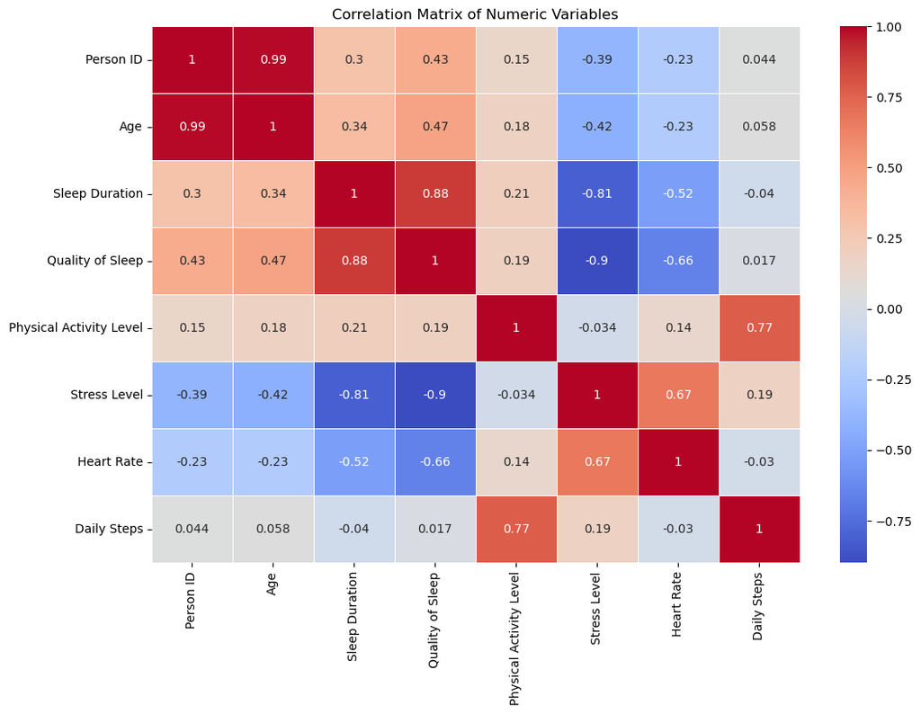

```python
# Calculate correlation matrix for numeric columns only
corr_matrix = data.select_dtypes(include=['number']).corr()

# Plot correlation heatmap
plt.figure(figsize=(12, 8))
sns.heatmap(corr_matrix, annot=True, cmap='coolwarm', linewidths=0.5)
plt.title("Correlation Matrix of Numeric Variables")
plt.show()
```

The correlation matrix reveals strong links among key variables: Sleep Duration and Sleep Quality are positively correlated, both negatively correlated with Stress Level, while Heart Rate shows moderate negative correlations with sleep and a positive correlation with stress. Daily Steps and Physical Activity Level are strongly positively correlated. Age and Person ID are highly correlated, likely due to sequential IDs, and should be excluded as predictors. Overall, stress, sleep, and activity show the clearest interconnections for analysis.

## 3. Feature engineering

```python
selected_cols = ['Gender', 'Age', 'Occupation', 'Sleep Duration', 'Quality of Sleep',
                 'Physical Activity Level', 'Stress Level', 'BMI Category', 'Heart Rate', 'Daily Steps',
                 'Sleep Disorder', 'Blood Pressure']


df = data[selected_cols].copy()


# Handling Categorical Variables¶
label_encoder_gender = LabelEncoder()
df['Gender'] = label_encoder_gender.fit_transform(df['Gender'])

occupation_mapping = {
    'Software Engineer': 0,
    'Doctor': 1,
    'Sales Representative': 2,
    'Salesperson': 2,
    'Teacher': 3,
    'Nurse': 4,
    'Engineer': 5,
    'Accountant': 6,
    'Scientist': 7,
    'Lawyer': 8,
    'Manager': 9
}
df['Occupation'] = df['Occupation'].map(occupation_mapping)

bmi_mapping = {
    'Overweight': 1,
    'Normal': 0,
    'Obese': 2,
    'Normal Weight': 0
}
df['BMI Category'] = df['BMI Category'].map(bmi_mapping)

df['UnderPressure'] = df['Blood Pressure'].apply(lambda x: int(x.split("/")[1]))
df['OverPressure'] = df['Blood Pressure'].apply(lambda x: int(x.split("/")[0]))
df = df.drop('Blood Pressure', axis=1)

sleep_mapping = {
    'None': 0,
    'Sleep Apnea': 1,
    'Insomnia': 2
}
df['Sleep Disorder'] = df['Sleep Disorder'].map(sleep_mapping)

features = ['Gender', 'Age', 'Occupation', 'Sleep Duration', 'Quality of Sleep',
            'Physical Activity Level', 'Stress Level', 'BMI Category', 'Heart Rate', 'Daily Steps',
            'UnderPressure', 'OverPressure', 'Sleep Disorder']
```

## 4. Split the data

```python
# Prepare the data¶
X = df[features].drop('Sleep Disorder', axis=1)
y = df['Sleep Disorder']

# Split the data into train and test sets¶
X_train, X_test, y_train, y_test = train_test_split(
    X, y, test_size=0.2, random_state=42, stratify=y
)
```

```python
X = df[features]
y = df['Sleep Disorder']

# One-hot encoding of the categorical columns
categorical_cols = ['Gender', 'Occupation', 'BMI Category']
X = pd.get_dummies(X, columns=categorical_cols, drop_first=True)

X_train, X_test, y_train, y_test = train_test_split(X, y, test_size=0.2, stratify=y, random_state=42)

# standardise the dataset
scaler = StandardScaler()
X_train = scaler.fit_transform(X_train)
X_test = scaler.transform(X_test)
```

## 5. Train the model (evaluate the model, hyperparameter turning, validate the model)

### machine Learning (K-Nearest neighbor, Random forest, supportvectoramchines and neural network)

```
Best k: 3
CV Best Accuracy: 0.9099999999999999

KNN Results:
Accuracy: 0.9067
Cohen's Kappa: 0.8334
Overall Precision: 0.9028
Overall Recall (Sensitivity): 0.8779
Overall F1-Score: 0.8895
```

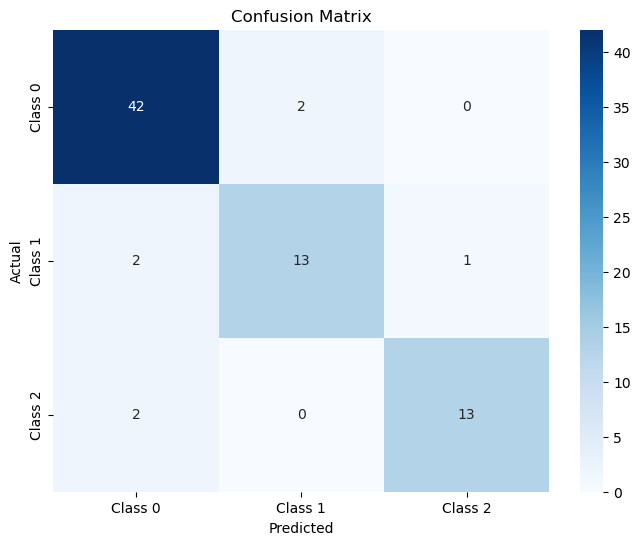

```python
# ----------------------------------------
# K-Nearest neighbor classification
# ----------------------------------------

# Define parameter grids for hyperparameter tuning cross-validation to find best k
k_values = [3, 5, 7, 9, 11, 13, 15, 17, 19, 21, 23]
param_grid = {'n_neighbors': k_values}

knn = KNeighborsClassifier()
cv = StratifiedKFold(n_splits=10, shuffle=True, random_state=42)

grid = GridSearchCV(knn, param_grid, cv=cv, scoring='accuracy')
grid.fit(X_train, y_train)

print("Best k:", grid.best_params_['n_neighbors'])
print("CV Best Accuracy:", grid.best_score_)


# Final KNN with best k
best_k = grid.best_params_['n_neighbors']
knn_final = KNeighborsClassifier(n_neighbors=best_k)
knn_final.fit(X_train, y_train)
y_pred = knn_final.predict(X_test)

# Confusion matrix and metrics
conf_matrix = confusion_matrix(y_test, y_pred)
accuracy = accuracy_score(y_test, y_pred)
kappa = cohen_kappa_score(y_test, y_pred)
precision = precision_score(y_test, y_pred, average='macro', zero_division=0)
recall = recall_score(y_test, y_pred, average='macro', zero_division=0)
f1 = f1_score(y_test, y_pred, average='macro', zero_division=0)

print("\nKNN Results:")
print(f"Accuracy: {accuracy:.4f}")
print(f"Cohen's Kappa: {kappa:.4f}")
print(f"Overall Precision: {precision:.4f}")
print(f"Overall Recall (Sensitivity): {recall:.4f}")
print(f"Overall F1-Score: {f1:.4f}")

def plot_conf_matrix(model, X_test, y_test):
    y_pred = model.predict(X_test)  # returns class labels
    cm = confusion_matrix(y_test, y_pred)

    plt.figure(figsize=(8, 6))
    sns.heatmap(cm, annot=True, fmt='d', cmap='Blues',
                xticklabels=['Class 0', 'Class 1', 'Class 2'],
                yticklabels=['Class 0', 'Class 1', 'Class 2'])
    plt.title('Confusion Matrix')
    plt.xlabel('Predicted')
    plt.ylabel('Actual')
    plt.show()

# Call the function with your trained KNN
plot_conf_matrix(knn_final, X_test, y_test)
```

```
Random Forest Results:
Accuracy: 0.9733
Cohen's Kappa: 0.9528
Overall Precision: 0.9718
Overall Recall: 0.9583
Overall F1-Score: 0.9633
```

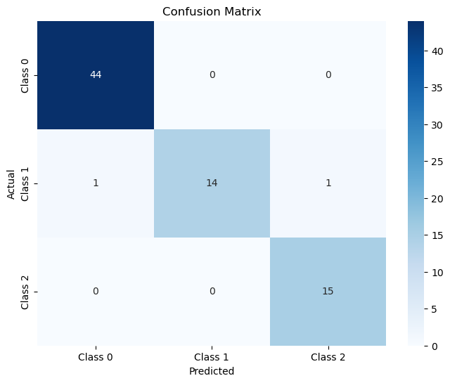

```python
# ------------------------------
# RANDOM FOREST
# ------------------------------

rf_model = RandomForestClassifier(n_estimators=200, max_features=3, random_state=42)
rf_model.fit(X_train, y_train)


# Prediction
rf_pred = rf_model.predict(X_test)

# Metrics
conf_matrix_rf = confusion_matrix(y_test, rf_pred)
accuracy_rf = accuracy_score(y_test, rf_pred)
kappa_rf = cohen_kappa_score(y_test, rf_pred)
precision_rf = precision_score(y_test, rf_pred, average='macro', zero_division=0)
recall_rf = recall_score(y_test, rf_pred, average='macro', zero_division=0)
f1_rf = f1_score(y_test, rf_pred, average='macro', zero_division=0)

print("\nRandom Forest Results:")
print(f"Accuracy: {accuracy_rf:.4f}")
print(f"Cohen's Kappa: {kappa_rf:.4f}")
print(f"Overall Precision: {precision_rf:.4f}")
print(f"Overall Recall: {recall_rf:.4f}")
print(f"Overall F1-Score: {f1_rf:.4f}")


def plot_conf_matrix(rf_pred, y_test):
    cm = confusion_matrix(y_test, rf_pred)
    plt.figure(figsize=(8, 6))
    sns.heatmap(cm, annot=True, fmt='d', cmap='Blues',
                xticklabels=['Class 0', 'Class 1', 'Class 2'],
                yticklabels=['Class 0', 'Class 1', 'Class 2'])
    plt.title('Confusion Matrix')
    plt.xlabel('Predicted')
    plt.ylabel('Actual')
    plt.show()

plot_conf_matrix(rf_pred, y_test)
```

The Random Forest model achieved a test accuracy of 97.3% and a Cohen’s Kappa of 0.953, indicating excellent agreement with the true labels. Its overall precision was 0.972, recall 0.958, and F1-score 0.963, reflecting strong predictive performance across all classes. The confusion matrix shows that almost all samples were correctly classified, with only minor misclassifications in class 1.

```
Best parameters: {'C': 2, 'gamma': 3.1249999999999996, 'kernel': 'rbf'}
Best CV accuracy: 0.9366666666666668

SVM Results:
Accuracy: 0.9600
Cohen's Kappa: 0.9280
Overall Precision: 0.9787
Overall Recall: 0.9361
Overall F1-Score: 0.9553
```

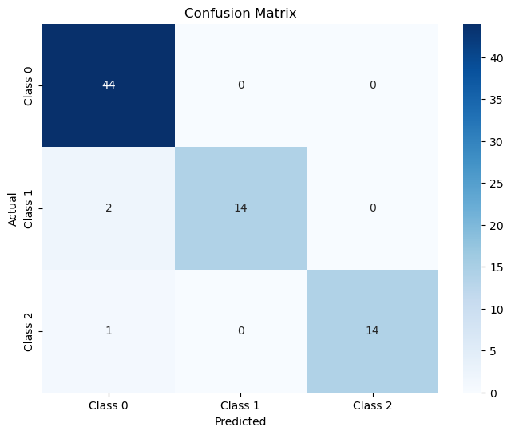

```python
# ------------------------------
# SUPPORT VECTOR MACHINE
# ------------------------------

# Hyperparameters (C och sigma)
C_values = [0.0001, 0.0005, 0.001, 0.005, 0.01, 0.05, 0.1, 0.7, 1, 2, 3, 4, 5, 10]
sigma_values = [0.1, 0.1, 0.3, 0.4, 0.015, 0.01, 0.0015, 0.001]

gamma_values = [1 / (2 * s**2) for s in sigma_values]

param_grid = {'C': C_values, 'gamma': gamma_values, 'kernel': ['rbf']}

# GridSearch med 10-fold CV
cv = StratifiedKFold(n_splits=10, shuffle=True, random_state=42)
svm_grid = GridSearchCV(SVC(), param_grid, cv=cv, scoring='accuracy', n_jobs=-1)
svm_grid.fit(X_train, y_train)

print("Best parameters:", svm_grid.best_params_)
print("Best CV accuracy:", svm_grid.best_score_)

# Training
svm_final = SVC(**svm_grid.best_params_)
svm_final.fit(X_train, y_train)

# Prediction on test set
y_pred_svm = svm_final.predict(X_test)

# Confusion matrix and metrics
conf_matrix_svm = confusion_matrix(y_test, y_pred_svm)
accuracy_svm = accuracy_score(y_test, y_pred_svm)
kappa_svm = cohen_kappa_score(y_test, y_pred_svm)
precision_svm = precision_score(y_test, y_pred_svm, average='macro', zero_division=0)
recall_svm = recall_score(y_test, y_pred_svm, average='macro', zero_division=0)
f1_svm = f1_score(y_test, y_pred_svm, average='macro', zero_division=0)

print("\nSVM Results:")
print(f"Accuracy: {accuracy_svm:.4f}")
print(f"Cohen's Kappa: {kappa_svm:.4f}")
print(f"Overall Precision: {precision_svm:.4f}")
print(f"Overall Recall: {recall_svm:.4f}")
print(f"Overall F1-Score: {f1_svm:.4f}")

def plot_conf_matrix(y_pred, y_test):
    cm = confusion_matrix(y_test, y_pred)
    plt.figure(figsize=(8, 6))
    sns.heatmap(cm, annot=True, fmt='d', cmap='Blues',
                xticklabels=['Class 0', 'Class 1', 'Class 2'],
                yticklabels=['Class 0', 'Class 1', 'Class 2'])
    plt.title('Confusion Matrix')
    plt.xlabel('Predicted')
    plt.ylabel('Actual')
    plt.show()

plot_conf_matrix(y_pred_svm, y_test)
```

The Support Vector Machine (SVM) with an RBF kernel, optimized with parameters C = 2 and gamma ≈ 3.125, achieved a cross-validated accuracy of 93.7%. On the test set, the model reached an accuracy of 96.0% and a Cohen’s Kappa of 0.928, indicating strong agreement with the true labels. The overall precision was 0.979, recall 0.936, and F1-score 0.955, demonstrating high predictive performance. The confusion matrix shows that most samples were correctly classified, with only minor misclassifications in classes 1 and 2.

```python
# ------------------------------
# Neural Network
# ------------------------------

# Create model, training and prediction
model = keras.Sequential([
    layers.Dense(64, activation='relu', input_shape=(X_train.shape[1],)),
    layers.BatchNormalization(),
    layers.Dropout(0.1),
    layers.Dense(32, activation='relu'),
    layers.BatchNormalization(),
    layers.Dropout(0.1),
    layers.Dense(3, activation='softmax')
])

optimizer = keras.optimizers.Adam(learning_rate=0.01)
model.compile(optimizer=optimizer, loss='sparse_categorical_crossentropy', metrics=['accuracy'])
res = model.fit(X_train, y_train, epochs=100, batch_size=32, validation_data=(X_test, y_test), verbose=0)

_, accuracy = model.evaluate(X_test, y_test, verbose=0)
print(f'Accuracy on test data: {accuracy * 100:.2f}%')
```

```
WARNING:absl:At this time, the v2.11+ optimizer `tf.keras.optimizers.Adam` runs slowly on M1/M2 Macs, please use the legacy Keras optimizer instead, located at `tf.keras.optimizers.legacy.Adam`.
```

```
Accuracy on test data: 96.00%
```

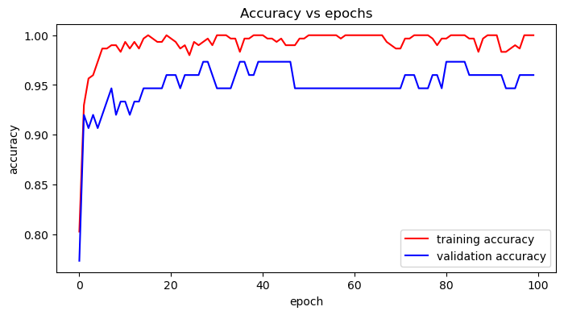

```python
# Visualize how the accuracy and loss vary over epochs
fig, ax = plt.subplots(1, 1, figsize=(8, 4))
ax.plot(res.history['accuracy'], 'r', label='training accuracy')
ax.plot(res.history['val_accuracy'], 'b', label='validation accuracy')
ax.set_xlabel('epoch')
ax.set_ylabel('accuracy')
ax.set_title('Accuracy vs epochs')
ax.legend()
plt.show()
```

```python
# Classification report
y_pred_probs = model.predict(X_test)
y_pred_classes = np.argmax(y_pred_probs, axis=1)

print("\nClassification Report:\n", classification_report(y_test, y_pred_classes))

kappa = cohen_kappa_score(y_test, y_pred_classes)
print(f"Kappa: {kappa}")
precision = precision_score(y_test, y_pred_classes, average='weighted')
recall = recall_score(y_test, y_pred_classes, average='weighted')
f1 = f1_score(y_test, y_pred_classes, average='weighted')

print(f"\nPrecision: {precision}, Recall: {recall}, F1-score: {f1}")
```

```
Classification Report:
               precision    recall  f1-score   support

           0       0.98      0.95      0.97        44
           1       0.88      0.94      0.91        16
           2       1.00      1.00      1.00        15

    accuracy                           0.96        75
   macro avg       0.95      0.96      0.96        75
weighted avg       0.96      0.96      0.96        75

Kappa: 0.9304697156983931

Precision: 0.9612585499316005, Recall: 0.96, F1-score: 0.9603761755485895
```

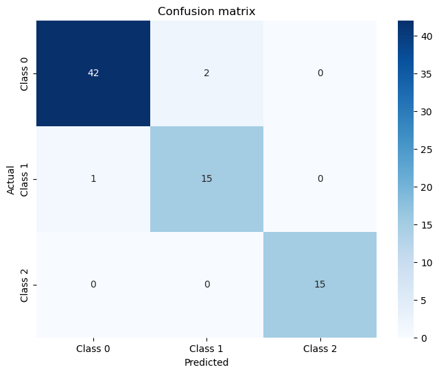

```python
def plot_conf_matrix(model, X_test, y_test):
    y_pred = model.predict(X_test)
    y_pred_classes = np.argmax(y_pred, axis=1)
    cm = confusion_matrix(y_test, y_pred_classes)
    plt.figure(figsize=(8, 6))
    sns.heatmap(cm, annot=True, fmt='d', cmap='Blues', xticklabels=['Class 0', 'Class 1', 'Class 2'], yticklabels=['Class 0', 'Class 1', 'Class 2'])
    plt.title('Confusion matrix')
    plt.xlabel('Predicted')
    plt.ylabel('Actual')
    plt.show()

plot_conf_matrix(model, X_test, y_test)
```

## Result

This dataset demonstrates that sleep health is influenced by a combination of demographic factors (gender, age), lifestyle factors (occupation, stress level), and physiological factors (BMI).

Insomnia seems more influenced by stress and age. Sleep Apnea is strongly associated with BMI and age. Occupation and gender mediate both stress and sleep disorder prevalence.

In short, sleep health is multifactorial, and both lifestyle and physiological characteristics significantly affect the likelihood of different sleep disorders.

Among the evaluated models, Random Forest demonstrated the best overall performance. It achieved a test accuracy of 97.3%, a Cohen’s Kappa of 0.953, and an F1-score of 0.963, with almost all samples correctly classified and only minor misclassifications in class 1.